# E1296_assignment_JIN_LILIN

Lilin Jin

25/02/2019

Using the UNGD corpus, analyse lexical richness and productivity. You can select a country or a sample of countries or years of your choice. Deploy relevant measures from `quanteda` and/or other packages (e.g. `sophistication`). You should read the two articles below (and on the Optional Readings list) in conjunction with Chapter 9 in the Corpus Linguistics textbook.

- Benoit, Kenneth, Kevin Munger, and Arthur Spirling. “Measuring and Explaining Political Sophistication through Textual Complexity.” Available at SSRN 3062061 (2018).
- Spirling, Arthur. “Democratization and linguistic complexity: The effect of franchise extension on parliamentary discourse, 1832–1915.” The Journal of Politics 78, no. 1 (2016): 120-136.

Formulate your own research question and develop your own research design. Be creative (but don’t go crazy with complicated anlaysis!), but treat it as a learning exercise.

# Data

Loading data from the UNGDC data

```r
#Loading packages and data
library(readtext)
library(quanteda)
library(dplyr)
library(tidyr)
library(readxl)
library(stringr)
```

```r
DATA_DIR <- "/Users/lilinjin/Desktop/Hertie Studies/Semester 4/Git_NLP/"

ungd_files <- readtext(paste0(DATA_DIR, "Converted sessions/*"),
                                 docvarsfrom = "filenames",
                                 dvsep="_",
                                 docvarnames = c("Country", "Session", "Year"))


ungd_files$doc_id <- str_replace(ungd_files$doc_id , ".txt", "") %>%
   str_replace(. , "_\\d{2}", "")
```

## Creating corpus object(s)

```r
ungd_corpus <- corpus(ungd_files, text_field = "text")

summary(ungd_corpus)
```

```
## Corpus consisting of 7897 documents, showing 100 documents:
##
##      Text Types Tokens Sentences Country Session Year
##  ALB_1970  1728   9078       256     ALB      25 1970
##  ARG_1970  1425   5192       218     ARG      25 1970
##  AUS_1970  1612   5690       270     AUS      25 1970
##  AUT_1970  1340   4717       164     AUT      25 1970
##  BEL_1970  1288   4786       207     BEL      25 1970
##  BLR_1970  1427   6138       204     BLR      25 1970
##  BOL_1970  1560   5613       225     BOL      25 1970
##  BRA_1970  1333   4427       154     BRA      25 1970
##  CAN_1970   728   1887        97     CAN      25 1970
##  CMR_1970   928   3144       106     CMR      25 1970
##  COG_1970  1071   3122       110     COG      25 1970
##  COL_1970  1787   6761       262     COL      25 1970
##  CRI_1970  1478   5453       206     CRI      25 1970
##  CUB_1970  1297   4501       182     CUB      25 1970
##  DOM_1970  1108   3919       128     DOM      25 1970
##  DZA_1970  1209   4452       171     DZA      25 1970
##  ECU_1970  1475   5146       190     ECU      25 1970
##  FRA_1970  1114   3496       144     FRA      25 1970
##  GBR_1970   939   3265       150     GBR      25 1970
##  GHA_1970  1236   4392       153     GHA      25 1970
##  GIN_1970  1083   3643       145     GIN      25 1970
##  GMB_1970  1363   4596       166     GMB      25 1970
##  GTM_1970   835   2591        98     GTM      25 1970
##  HND_1970   998   2908       100     HND      25 1970
##  HTI_1970  1332   4075        96     HTI      25 1970
##  IDN_1970  1072   3187       144     IDN      25 1970
##  IND_1970  1182   3917       183     IND      25 1970
##  IRN_1970  1059   3244       162     IRN      25 1970
##  IRQ_1970  1152   4243       157     IRQ      25 1970
##  ISL_1970  1040   3893       159     ISL      25 1970
##  ISR_1970  2108   8569       368     ISR      25 1970
##  ITA_1970   881   2705        98     ITA      25 1970
##  JPN_1970   981   3669       139     JPN      25 1970
##  KEN_1970  1224   3772       194     KEN      25 1970
##  KHM_1970  1307   4984       152     KHM      25 1970
##  KWT_1970   987   3019       122     KWT      25 1970
##  LBN_1970   678   1877        76     LBN      25 1970
```

[output cut: 52 more lines]

```
##  COD_1971  1246   4313       168     COD      26 1971
##  COG_1971  1274   4053       134     COG      26 1971
##  COL_1971  1587   5818       204     COL      26 1971
##  CSK_1971   858   2840       114     CSK      26 1971
##  CUB_1971  1090   3831       137     CUB      26 1971
##  CYP_1971  1269   5023       173     CYP      26 1971
##  DOM_1971  1384   5376       202     DOM      26 1971
##  DZA_1971  1451   5474       183     DZA      26 1971
##  ECU_1971  1432   5157       169     ECU      26 1971
##  EGY_1971  1461   6721       285     EGY      26 1971
##  ESP_1971  1257   4069       173     ESP      26 1971
##
## Source: /Users/lilinjin/Desktop/Hertie Studies/Semester 4/Git_NLP/* on x86_64 by lilinjin
## Created: Mon Feb 25 23:19:39 2019
## Notes:
```

```r
ungd_US <- corpus_subset(ungd_corpus, Country == "USA")

ungd_US_before <- corpus_subset(ungd_US, Year < 1992)

ungd_US_after<- corpus_subset(ungd_US, Year > 1991)
```

```r
#Tokenization and basic pre-processing
tok_US_before <- tokens(ungd_US_before, what = "word",
              remove_punct = TRUE,
              remove_symbols = TRUE,
              remove_numbers = TRUE,
              remove_twitter = TRUE,
              remove_url = TRUE,
              remove_hyphens = FALSE,
              verbose = TRUE,
              include_docvars = TRUE)
```

```
## Starting tokenization...
```

```
## ...tokenizing 1 of 1 blocks
```

```
## ...preserving hyphens
```

```
## ...removing URLs
```

```
## ...serializing tokens 7912 unique types
## ...total elapsed:  0.244999999999997 seconds.
## Finished tokenizing and cleaning 22 texts.
```

```r
tok_US_after <- tokens(ungd_US_after, what = "word",
              remove_punct = TRUE,
              remove_symbols = TRUE,
              remove_numbers = TRUE,
              remove_twitter = TRUE,
              remove_url = TRUE,
              remove_hyphens = FALSE,
              verbose = TRUE,
              include_docvars = TRUE)
```

```
## Starting tokenization...
## ...tokenizing 1 of 1 blocks
## ...preserving hyphens
## ...removing URLs
## ...serializing tokens 7427 unique types
## ...total elapsed:  0.146000000000001 seconds.
## Finished tokenizing and cleaning 26 texts.
```

```r
#tokenisation for US during cold war
tok_US_be <- tokens_tolower(tok_US_before)

tok_US_bef <- tokens_select(tok_US_be, stopwords("english"), selection = "remove", padding = FALSE)

tok_US_b <- tokens(tok_US_bef, ngrams = c(1:2), include_docvars = TRUE)

# after cold war
tok_US_af <- tokens_tolower(tok_US_after)

tok_US_aft <- tokens_select(tok_US_af, stopwords("english"), selection = "remove", padding = FALSE)

tok_US_a <- tokens(tok_US_aft, ngrams = c(1:2), include_docvars = TRUE)
```

```r
dfm_US_b <- dfm(tok_US_b)
dfm_US_a <- dfm(tok_US_a)
```

```r
# most frequent words during cold war
freq_US_before <- textstat_frequency(dfm_US_b)

head(freq_US_before, n=20)
```

```
##           feature frequency rank docfreq group
## 1          united       826    1      22   all
## 2         nations       685    2      22   all
## 3          states       521    3      22   all
## 4           world       457    4      22   all
## 5   united_states       449    5      22   all
## 6           peace       396    6      22   all
## 7             can       355    7      22   all
## 8  united_nations       347    8      22   all
## 9            must       343    9      22   all
## 10  international       312   10      22   all
## 11            new       261   11      21   all
## 12        nuclear       230   12      20   all
## 13       economic       225   13      21   all
## 14             us       224   14      22   all
## 15          human       203   15      22   all
## 16         people       201   16      22   all
## 17         soviet       195   17      22   all
## 18            now       180   18      21   all
## 19            one       176   19      22   all
## 20       progress       174   20      22   all
```

```r
# most frequent words after cold war

freq_US_after <- textstat_frequency(dfm_US_a)

head(freq_US_after, n=20)
```

```
##           feature frequency rank docfreq group
## 1         nations       859    1      26   all
## 2          united       743    2      26   all
## 3          people       563    3      26   all
## 4           world       505    4      26   all
## 5  united_nations       459    5      26   all
## 6            must       457    6      26   all
## 7             can       376    7      26   all
## 8          states       352    8      26   all
## 9              us       294    9      26   all
## 10          peace       284   10      25   all
## 11  united_states       270   11      26   all
## 12       security       238   12      26   all
## 13            new       234   13      26   all
## 14          human       203   14      26   all
## 15          every       190   15      26   all
## 16           work       186   16      26   all
## 17  international       185   17      25   all
## 18        weapons       184   18      26   all
## 19           also       175   19      26   all
## 20       together       174   20      25   all
```

```r
# lexical diversity before vs. after
lexdiv_US_before <- textstat_lexdiv(dfm_US_b)
head(lexdiv_US_before)
```

```
##   document       TTR
## 1 USA_1970 0.6784452
## 2 USA_1971 0.7008529
## 3 USA_1972 0.7250694
## 4 USA_1973 0.7856370
## 5 USA_1974 0.7184193
## 6 USA_1975 0.6982744
```

```r
lexdiv_US_after <- textstat_lexdiv(dfm_US_a)
head(lexdiv_US_after)
```

```
##   document       TTR
## 1 USA_1992 0.7102041
## 2 USA_1993 0.6965078
## 3 USA_1994 0.7356828
## 4 USA_1995 0.7299429
## 5 USA_1996 0.7159763
## 6 USA_1997 0.7457152
```

```r
mean(lexdiv_US_before$TTR)
```

```
## [1] 0.724058
```

```r
mean(lexdiv_US_after$TTR)
```

```
## [1] 0.7314706
```

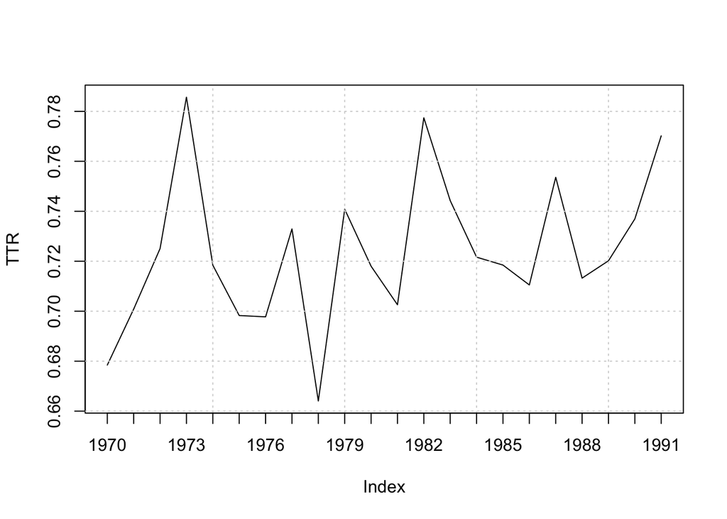

```r
# plot the TTR before vs after
plot(lexdiv_US_before$TTR, type = 'l', xaxt = 'n', xlab = NULL, ylab = "TTR")
grid()
axis(1, at = seq_len(nrow(lexdiv_US_before)), labels = docvars(dfm_US_b, 'Year'))
```

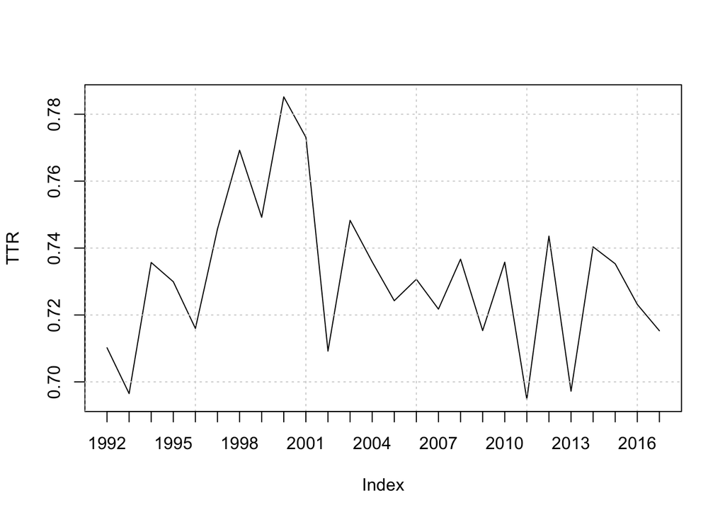

```r
plot(lexdiv_US_after$TTR, type = 'l', xaxt = 'n', xlab = NULL, ylab = "TTR")
grid()
axis(1, at = seq_len(nrow(lexdiv_US_after)), labels = docvars(dfm_US_a, 'Year'))
```

During the cold war, the TTR is on average lower (0.724) than the after-war time(0.731), the lowest appears in year 1978.

```r
period <- ifelse(docvars(ungd_US, "Year") < 1992, "cold_war", "post_cold_war")
dfmat <- dfm(ungd_US, groups = period)
head(tstat <- textstat_keyness(dfmat), 10)
```

```
##         feature      chi2            p n_target n_reference
## 1        soviet 158.53620 0.000000e+00      195          12
## 2         which 110.76205 0.000000e+00      314          97
## 3             .  87.68602 0.000000e+00     5342        4351
## 4           the  84.02940 0.000000e+00     6899        5780
## 5            of  83.74242 0.000000e+00     4082        3244
## 6          arms  83.65617 0.000000e+00      131          18
## 7  co-operation  75.59519 0.000000e+00       77           0
## 8      economic  73.56040 0.000000e+00      225          74
## 9  negotiations  73.54304 0.000000e+00      120          18
## 10        union  69.33577 1.110223e-16      126          23
```

```r
tail(tstat, 10)
```

```
##          feature       chi2            p n_target n_reference
## 10516      their  -58.63298 1.898481e-14      290         497
## 10517        our  -60.02441 9.325873e-15      655         949
## 10518        and  -66.55221 3.330669e-16     3017        3608
## 10519 terrorists  -71.79369 0.000000e+00        9          94
## 10520    america  -75.49829 0.000000e+00       42         165
## 10521   children  -82.01731 0.000000e+00       14         116
## 10522       iraq  -87.35807 0.000000e+00       16         126
## 10523        who -111.84352 0.000000e+00      109         325
## 10524       that -150.91919 0.000000e+00     1245        1899
## 10525     people -179.07053 0.000000e+00      201         563
```

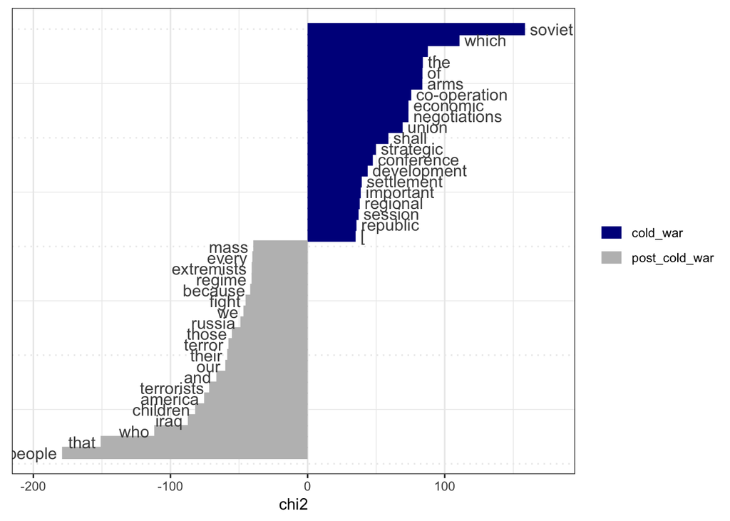

```r
textplot_keyness(tstat)
```

According to the keyness score, which measures features that occur differentially across different categories, we can see significant differences in the use of words by the US during and after the cold war.“Soviet”, “co-operation”, “negotiation” are of highly significant usage during the cold war. However, in the post-cold-war era, they were replaced by words such as “people”,“terrorists”, and “Russia”, reflecting a shift of the focus of US foreign policy.